# Delta Hedge Portfolio Simulation and Errors by Delta Position Update Frequency

This notebook uses Geometric Brownian Motion and the Black-Scholes Model to simulate option value and how to delta hedge a long call option position. The simulation is repeated where the time step frequency in which the delta hedge is adjusted to analyze the distribution of expected returns from the overall portfolio position per option unit.

```python
import numpy as np
import matplotlib.pyplot as plt
from scipy.stats import lognorm, norm
import statsmodels.api as sm
import pylab

np.random.seed(2)
```

First, a function to simulate GBM paths is created. Input parameters are set to reflect an option that expires a year from the current date. The current price of the underlying is \$100 with a volatility of 20\% (annualized). The number of time steps is set to 252 to reflect the amount of trading days in a year, so each time step represents one day. For the sake of simplicity, the risk free rate is set to 0\% so the option value is not discounted over time.

```python
def generate_gbm_paths(starting_price, volatility, risk_free_rate, num_time_steps, time_to_maturity, num_simulations):

    dt = time_to_maturity / num_time_steps
    Z = np.random.normal(0, 1, (num_simulations, num_time_steps))
    drift = (risk_free_rate - 0.5 * volatility ** 2) * dt
    diffusion = volatility * np.sqrt(dt) * Z
    stock_prices_matrix = np.zeros((num_simulations, num_time_steps + 1))
    stock_prices_matrix[:, 0] = starting_price
    for i in range(num_time_steps):
        stock_prices_matrix[:, i + 1] = stock_prices_matrix[:, i] * np.exp(drift + diffusion[:, i])

    return stock_prices_matrix
```

```python
starting_price = 100.0
volatility = 0.2
risk_free_rate = 0
num_time_steps = 252
time_to_maturity = 1.0
num_simulations = 10

stock_prices_paths = generate_gbm_paths(starting_price, volatility, risk_free_rate, num_time_steps, time_to_maturity, num_simulations)
stock_prices_paths.shape
```

```
(10, 253)
```

We can plot the realized price paths of 10 random simulations.

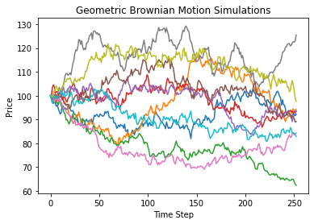

```python
plt.plot(stock_prices_paths.T)
plt.title("Geometric Brownian Motion Simulations")
plt.xlabel("Time Step")
plt.ylabel("Price")
plt.show()
```

Let's increase the number of simulations to 10\,000.

```python
num_simulations = 10_000
stock_prices_paths = generate_gbm_paths(starting_price, volatility, risk_free_rate, num_time_steps, time_to_maturity, num_simulations)
```

Since the value of each simulation at each time step represents the price of the underlying, we can derive the empirical distribution of prices from the simulation. We plot the distribution of the prices at the last time step overlaid with a log-normal distribution of the above parameters to validate our simulation.

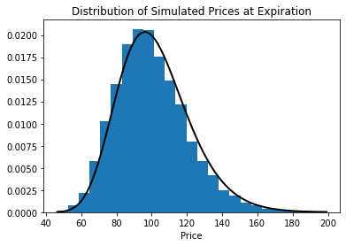

```python
S_f = stock_prices_paths[:,-1]
plt.hist(S_f, bins = 25, density = True)
x = np.linspace(min(S_f), max(S_f), 100)
pdf = lognorm.pdf(x, scale = starting_price, s = volatility)
plt.plot(x, pdf, 'k', linewidth = 2)
plt.title("Distribution of Simulated Prices at Expiration")
plt.xlabel("Price")
plt.show()
```

We now create a function that evaluates and returns the fair value of a call option and it's delta using the Black-Scholes model. Note that if $C(s, t) = $ the value of the option at time $t$ and price $s$, then $\frac{\partial C}{\partial S}(s, t) = \Delta (s, t)$, or the rate of change in the value of the option in respect to price, is the delta value. For our application of a call option, the delta will range between 0 and 1. We test the function for an at-the-money option.

```python
def black_scholes_call_delta(S, K, T, r, sigma):

    d1 = (np.log(S / K) + (r + 0.5 * sigma**2) * T) / (sigma * np.sqrt(T))
    d2 = d1 - sigma * np.sqrt(T)

    call_option_value = S * norm.cdf(d1) - K * np.exp(-r * T) * norm.cdf(d2)
    call_option_delta = norm.cdf(d1)

    return call_option_value, call_option_delta
```

```python
strike_price = starting_price
V, delta = black_scholes_call_delta(starting_price, strike_price, time_to_maturity, risk_free_rate, volatility)
V, delta
```

```
(7.965567455405804, 0.539827837277029)
```

We now create a simulation that will generate random prices and loop through each time step to value the option over each simulation and delta hedge the position. We will keep track of the option value and value of outright position in the underlying determined by the delta. Our short position in the underlying will be re-calculated from the delta at time steps with frequency inputted by the user. Thus, our total portfolio profit-and-loss per option unit held will be logged over each simulation and time step (ignoring transaction costs).

$$PnL(p_x(t), t) = [C(p_x(t), t) - C(p_x(t-1), t-1)] + \Delta(p_x(t-1), t-1)[p_x(t) - p_x(t-1)]$$

Where $p_x(t)$ is the price at time $t$ for simulation index $x$.

```python
def simulate_porfolio(starting_price, strike_price, volatility, risk_free_rate, num_time_steps, time_to_maturity, num_simulations, delta_dt_intv = 1):

    stock_prices_paths = generate_gbm_paths(starting_price, volatility, risk_free_rate, num_time_steps, time_to_maturity, num_simulations)
    dt = time_to_maturity / num_time_steps
    T = time_to_maturity
    call_option_value = np.empty((0, num_simulations))
    call_option_delta = np.empty((0, num_simulations))
    delta_time = 0
    for t in range(stock_prices_paths.shape[1] - 1):
        prices = stock_prices_paths[:, t]
        time_to_maturity = T - dt * t
        call_option_value_t, call_option_delta_t = black_scholes_call_delta(prices, strike_price, time_to_maturity, risk_free_rate, volatility)
        call_option_value = np.vstack((call_option_value, call_option_value_t))
        call_option_delta = np.vstack((call_option_delta, call_option_delta_t))

        if t == 0:
            option_PnL = np.zeros((1, num_simulations))
            asset_PnL = np.zeros((1, num_simulations))
        else:
            option_PnL_t = call_option_value[t, :] - call_option_value[t-1, :] + option_PnL[t-1, :]
            option_PnL = np.vstack((option_PnL, option_PnL_t))
            asset_PnL_t = -call_option_delta[delta_time, :] * (stock_prices_paths[:, t] - stock_prices_paths[:, t-1]) + asset_PnL[t-1, :]
            asset_PnL = np.vstack((asset_PnL, asset_PnL_t))
            if t % delta_dt_intv == 0:
                delta_time = t


    portfolio_PnL = option_PnL + asset_PnL
    return portfolio_PnL.T, option_PnL.T, asset_PnL.T, call_option_value.T, call_option_delta.T, stock_prices_paths
```

Lets run the delta hedge simulation adjusting our delta position each time step and plot the values for the simulation that had highest and lowest error at the last time step. Notice how the portfolio's PnL stays close to zero across the time interval. This is the goal of delta hedging. Since the delta is not constant (see gamma = change in delta with respect to price), delta hedging will not always be perfect - especially when there are large price movements. Lets also plot the distribution of the portfolio's PnL at the last time step for all simulations. As expected, the returns are centered around zero - the delta hedging goal. Lasty, while the distributed returns look symmetric, a q-q plot shows that it is not normally distributed (it is actually has a higher kurtosis).

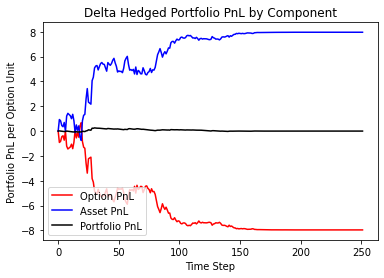

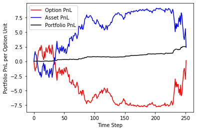

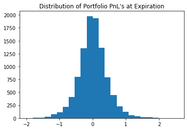

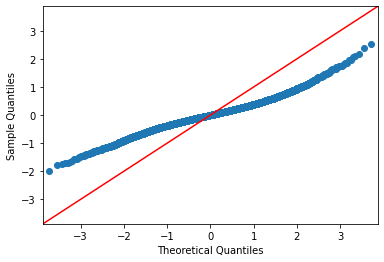

```python
num_simulations = 10_000
portfolio_PnL, option_PnL, asset_PnL, call_option_value, call_option_delta, stock_prices_paths = simulate_porfolio(starting_price, strike_price, volatility, risk_free_rate, num_time_steps, time_to_maturity, num_simulations)

min_error_index = np.argmin(abs(portfolio_PnL[:, -1]))
max_error_index = np.argmax(abs(portfolio_PnL[:, -1]))

plt.plot(option_PnL[min_error_index, :], "red", label = "Option PnL")
plt.plot(asset_PnL[min_error_index, :], "blue", label = "Asset PnL")
plt.plot(portfolio_PnL[min_error_index, :], "black", label = "Portfolio PnL")
plt.title("Delta Hedged Portfolio PnL by Component")
plt.xlabel("Time Step")
plt.ylabel("Portfolio PnL per Option Unit")
plt.legend()
plt.show()

plt.plot(option_PnL[max_error_index, :], "red", label = "Option PnL")
plt.plot(asset_PnL[max_error_index, :], "blue", label = "Asset PnL")
plt.plot(portfolio_PnL[max_error_index, :], "black", label = "Portfolio PnL")
plt.xlabel("Time Step")
plt.ylabel("Portfolio PnL per Option Unit")
plt.legend()
plt.show()

plt.hist(portfolio_PnL[:, -1], bins = 25)
plt.title("Distribution of Portfolio PnL's at Expiration")
plt.show()

sm.qqplot(portfolio_PnL[:, -1], line='45')
pylab.show()
```

Now lets see how decreasing the number of times we adjust our delta position (by increasing the delta intervals) adjusts our portfolio returns. We will run the simulation on delta adjustment intervals of $\{1, 2, ..., 10\}$.

```python
num_simulations = 10_000

d_intvs = range(1, 11)
stds_PnL = np.empty((0, num_simulations))
for d_intv in d_intvs:
    portfolio_PnL, option_PnL, asset_PnL, call_option_value, call_option_delta, stock_prices_paths = simulate_porfolio(starting_price, strike_price, volatility, risk_free_rate, num_time_steps, time_to_maturity, num_simulations, delta_dt_intv = d_intv)
    stds_PnL = np.vstack((stds_PnL, portfolio_PnL[:, -1]))
```

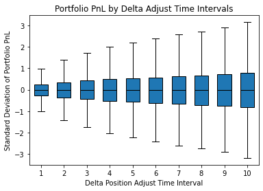

```python
fig, ax = plt.subplots()
num_rows = stds_PnL.shape[0]
for row_idx in range(num_rows):
        row_data = stds_PnL[row_idx]
        boxplot = ax.boxplot(row_data, positions = [row_idx + 1], showfliers = False,
                            patch_artist = True, medianprops = dict(color='black'),
                            widths = 0.6)

plt.title("Portfolio PnL by Delta Adjust Time Intervals")
plt.xlabel("Delta Position Adjust Time Interval")
plt.ylabel("Standard Deviation of Portfolio PnL")
plt.show()
```

As expected, the variance of the distribution of returns (or delta hedge errors) increases as we refrain from updating our delta positions. Thus, this simulation highlights the importance of frequently updating delta hedged positions and considering gamma to aid in doing this.